# BasicGraphAssignment

```python
%matplotlib inline
```

```python
import matplotlib.pyplot as plt
```

```python
import pandas as pd
```

```python
df_OpVA = pd.read_csv('C:\\Users\\mohammed.shehadeh\\CTBA\\CTBA\\M2\\OpidsVA.csv')
```

```python
df_OpVA
```

|  | FIPSCode | CountyName | FFHO-Rate | FPOO-Rate | HIV-Rate | MedianHouseholdIncome |
| --- | --- | --- | --- | --- | --- | --- |
| 0 | 51001 | Accomack | 12.1 | 12.1 | 3.0 | 39040 |
| 1 | 51003 | Albemarle | 0.9 | 0.9 | 2.8 | 73132 |
| 2 | 51005 | Alleghany | 6.4 | 12.8 | 6.4 | 47037 |
| 3 | 51007 | Amelia | 7.7 | 0.0 | 7.7 | 56172 |
| 4 | 51009 | Amherst | 3.2 | 6.3 | 6.3 | 46497 |
| 5 | 51011 | Appomattox | 12.9 | 6.5 | 0.0 | 51431 |
| 6 | 51013 | Arlington | 6.1 | 4.8 | 13.5 | 108635 |
| 7 | 51015 | Augusta | 0.0 | 2.7 | 2.7 | 56784 |
| 8 | 51017 | Bath | 0.0 | 0.0 | 0.0 | 47059 |
| 9 | 51019 | Bedford | 1.3 | 2.6 | 2.6 | 55708 |
| 10 | 51021 | Bland | 0.0 | 0.0 | 0.0 | 44827 |
| 11 | 51023 | Botetourt | 3.0 | 6.0 | 3.0 | 68390 |
| 12 | 51025 | Brunswick | 6.2 | 0.0 | 18.5 | 39433 |
| 13 | 51027 | Buchanan | 0.0 | 13.5 | 0.0 | 31763 |
| 14 | 51029 | Buckingham | 0.0 | 0.0 | 23.5 | 42455 |
| 15 | 51031 | Campbell | 3.6 | 9.1 | 3.6 | 49935 |
| 16 | 51033 | Caroline | 13.3 | 16.6 | 6.6 | 55423 |
| 17 | 51035 | Carroll | 0.0 | 0.0 | 0.0 | 40390 |
| 18 | 51036 | Charles City | 14.1 | 0.0 | 0.0 | 56907 |
| 19 | 51037 | Charlotte | 0.0 | 0.0 | 8.2 | 38557 |
| 20 | 51041 | Chesterfield | 14.2 | 4.4 | 13.9 | 76260 |
| 21 | 51043 | Clarke | 20.9 | 0.0 | 13.9 | 76753 |
| 22 | 51045 | Craig | 19.4 | 0.0 | 0.0 | 48221 |
| 23 | 51047 | Culpeper | 28.0 | 6.0 | 8.0 | 67023 |
| 24 | 51049 | Cumberland | 10.4 | 0.0 | 10.4 | 42692 |
| 25 | 51051 | Dickenson | 0.0 | 40.1 | 13.4 | 32795 |
| 26 | 51053 | Dinwiddie | 7.1 | 3.6 | 7.1 | 54805 |
| 27 | 51057 | Essex | 9.0 | 9.0 | 18.0 | 50033 |
| 28 | 51059 | Fairfax | 5.5 | 3.0 | 10.0 | 115518 |
| 29 | 51061 | Fauquier | 26.1 | 13.0 | 7.2 | 91372 |
| ... | ... | ... | ... | ... | ... | ... |
| 103 | 51595 | Emporia | 0.0 | 0.0 | 0.0 | 33499 |
| 104 | 51600 | Fairfax | 0.0 | 4.1 | 4.1 | 94701 |
| 105 | 51610 | Falls Church | 0.0 | 0.0 | 0.0 | 118035 |
| 106 | 51620 | Franklin | 0.0 | 0.0 | 12.0 | 40247 |
| 107 | 51630 | Fredericksburg | 28.3 | 10.6 | 10.6 | 53714 |
| 108 | 51640 | Galax | 0.0 | 0.0 | 0.0 | 35221 |
| 109 | 51650 | Hampton | 14.8 | 6.6 | 35.4 | 50294 |
| 110 | 51660 | Harrisonburg | 5.7 | 3.8 | 3.8 | 41636 |
| 111 | 51670 | Hopewell | 30.8 | 8.8 | 26.4 | 40126 |
| 112 | 51678 | Lexington | 0.0 | 14.2 | 0.0 | 45331 |
| 113 | 51680 | Lynchburg | 5.0 | 2.5 | 11.2 | 41586 |
| 114 | 51683 | Manassas | 14.5 | 9.6 | 4.8 | 72396 |
| 115 | 51685 | Manassas Park | 6.3 | 0.0 | 6.3 | 75994 |
| 116 | 51690 | Martinsville | 0.0 | 0.0 | 14.9 | 34262 |
| 117 | 51700 | Newport News | 13.2 | 11.0 | 15.9 | 50149 |
| 118 | 51710 | Norfolk | 24.1 | 9.0 | 31.8 | 45809 |
| 119 | 51720 | Norton | 0.0 | 25.9 | 0.0 | 30587 |
| 120 | 51730 | Petersburg | 31.4 | 18.8 | 34.5 | 34238 |
| 121 | 51735 | Poquoson | 25.0 | 8.3 | 0.0 | 90119 |
| 122 | 51740 | Portsmouth | 26.2 | 8.4 | 27.3 | 46617 |
| 123 | 51750 | Radford | 5.7 | 11.4 | 5.7 | 35655 |
| 124 | 51760 | Richmond | 30.0 | 9.0 | 27.3 | 42336 |
| 125 | 51770 | Roanoke | 7.0 | 4.0 | 8.0 | 38238 |
| 126 | 51775 | Salem | 15.7 | 3.9 | 7.8 | 57897 |
| 127 | 51790 | Staunton | 4.1 | 8.2 | 8.2 | 46237 |
| 128 | 51800 | Suffolk | 4.5 | 4.5 | 15.7 | 65025 |
| 129 | 51810 | Virginia Beach | 12.4 | 6.4 | 13.9 | 70596 |
| 130 | 51820 | Waynesboro | 0.0 | 0.0 | 4.6 | 41255 |
| 131 | 51830 | Williamsburg | 13.1 | 0.0 | 6.6 | 49231 |
| 132 | 51840 | Winchester | 29.1 | 14.5 | 7.3 | 46093 |

133 rows × 6 columns

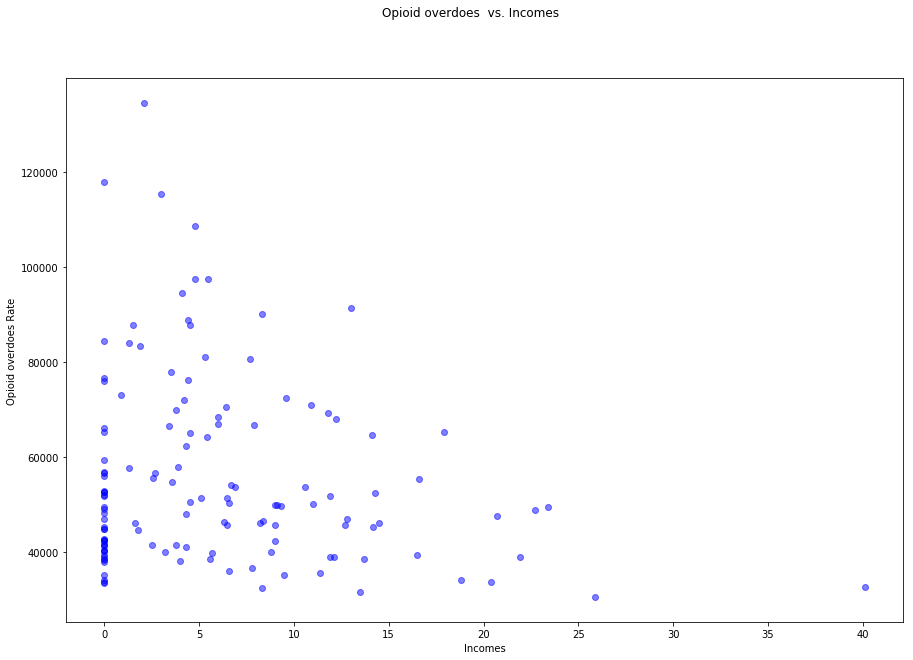

```python
""" Format of the scatterplot method is as follows: ax.scatter(x-series, y-series) """
fig, ax = plt.subplots()

ax.scatter(df_OpVA['FPOO-Rate'], df_OpVA['MedianHouseholdIncome'], alpha=0.5, c = 'b')    # the 'alpha' parameter controls dot opacity
fig.suptitle('Opioid overdoes  vs. Incomes')
ax.xaxis.set_label_text('Incomes')
ax.yaxis.set_label_text('Opioid overdoes Rate')

fig.set_size_inches(15,10)
plt.show()
```

### Question: Do opioid overdoes tend to be associated with less affluent areas—that is, areas where families have lower incomes?

Per chart above, where i determined scatterplot is the most appropriate graph for this type of data, it's noted a negative relationship between Opioid Overdoes rate and the income, hence, the lowe the income, the higher the rate for Opioid overdoes.

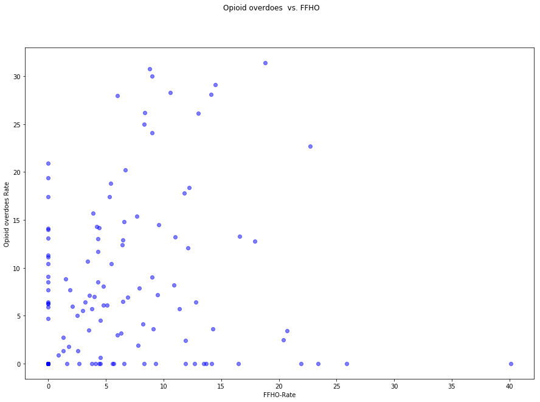

```python
fig, ax = plt.subplots()

ax.scatter(df_OpVA['FPOO-Rate'], df_OpVA['FFHO-Rate'], alpha=0.5, c = 'b')    # the 'alpha' parameter controls dot opacity
fig.suptitle('Opioid overdoes  vs. FFHO')
ax.xaxis.set_label_text('FFHO-Rate')
ax.yaxis.set_label_text('Opioid overdoes Rate')

fig.set_size_inches(15,10)
plt.show()
```

### Question: Some people who start with opioid addictions are reported to transition to heroin use. What is the relationship in Virginia counties between opioid overdoses and heroin overdoses?

Per chart above, where i determined scatterplot is the most appropriate graph for this type of data, it's noted a postive relationship between Opioid Overdoes rate and the heroin use, hence, the higher the use of Opioid the more likly the use of heroin.

```python
df_Prst = pd.read_csv('C:\\Users\\mohammed.shehadeh\\CTBA\\CTBA\\M2\\presidents.csv')
```

```python
df_Prst
```

|  | Name | Location | State |
| --- | --- | --- | --- |
| 0 | George Washington | Westmoreland County | Virginia |
| 1 | John Adams | Braintree | Massachusetts |
| 2 | Thomas Jefferson | Shadwell | Virginia |
| 3 | James Madison | Port Conway | Virginia |
| 4 | James Monroe | Monroe Hall | Virginia |
| 5 | Andrew Jackson | Waxhaws Region | South/North Carolina |
| 6 | John Quincy Adams | Braintree | Massachusetts |
| 7 | William Henry Harrison | Charles City County | Virginia |
| 8 | Martin Van Buren | Kinderhook | New York |
| 9 | Zachary Taylor | Barboursville | Virginia |
| 10 | John Tyler | Charles City County | Virginia |
| 11 | James Buchanan | Cove Gap | Pennsylvania |
| 12 | James K. Polk | Pineville | North Carolina |
| 13 | Millard Fillmore | Summerhill | New York |
| 14 | Franklin Pierce | Hillsborough | New Hampshire |
| 15 | Andrew Johnson | Raleigh | North Carolina |
| 16 | Abraham Lincoln | Sinking Spring | Kentucky |
| 17 | Ulysses S. Grant | Point Pleasant | Ohio |
| 18 | Rutherford B. Hayes | Delaware | Ohio |
| 19 | James A. Garfield | Moreland Hills | Ohio |
| 20 | Chester A. Arthur | Fairfield | Vermont |
| 21 | Benjamin Harrison | North Bend | Ohio |
| 22 | Grover Cleveland | Caldwell | New Jersey |
| 23 | William McKinley | Niles | Ohio |
| 24 | Woodrow Wilson | Staunton | Virginia |
| 25 | William H. Taft | Cincinnati | Ohio |
| 26 | Theodore Roosevelt | New York City | New York |
| 27 | Warren G. Harding | Blooming Grove | Ohio |
| 28 | Calvin Coolidge | Plymouth | Vermont |
| 29 | Herbert Hoover | West Branch | Iowa |
| 30 | Franklin D. Roosevelt | Hyde Park | New York |
| 31 | Harry S. Truman | Lamar | Missouri |
| 32 | Dwight D. Eisenhower | Denison | Texas |
| 33 | Lyndon B. Johnson | Stonewall | Texas |
| 34 | Ronald Reagan | Tampico | Illinois |
| 35 | Richard Nixon | Yorba Linda | California |
| 36 | Gerald Ford | Omaha | Nebraska |
| 37 | John F. Kennedy | Brookline | Massachusetts |
| 38 | George H. W. Bush | Milton | Massachusetts |
| 39 | Jimmy Carter | Plains | Georgia |
| 40 | Donald Trump | Queens, New York City | New York |
| 41 | George W. Bush | New Haven | Connecticut |
| 42 | Bill Clinton | Hope | Arkansas |
| 43 | Barack Obama | Honolulu | Hawaii |

```python
Name = df_Prst['Name']
```

```python
State = df_Prst['State']
```

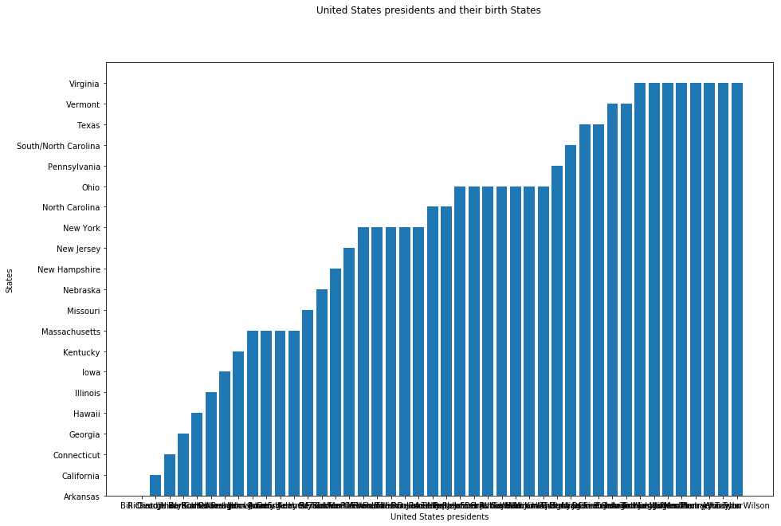

```python
fig,ax = plt.subplots()
fig.suptitle('United States presidents and their birth States')
ax.xaxis.set_label_text('United States presidents')
ax.yaxis.set_label_text('States')
fig.set_size_inches(15,10)

PresState = [(Name[i],State[i]) for i in range(len(Name))]
PresState.sort(key = lambda x:x[1], reverse=False)
PresPlot = [x[0] for x in PresState]
StateBir = [x[1] for x in PresState]


ax.bar(PresPlot,StateBir)
plt.show()
```

### Question: Which states are associated with the greatest number of United States presidents in terms of the presidents’ birthplaces?

Using Bar chart is the appropriate way to graph this type of Data. Per above Virginia is the State with most associated with the greatest number of US presidents.

```python
import pandas as pd
df_TNSA = pd.read_csv('C:\\Users\\mohammed.shehadeh\\CTBA\\CTBA\\M2\\TOTALNSA.csv')
```

```python
df_TNSA
```

|  | DATE | TOTALNSA |
| --- | --- | --- |
| 0 | 1976-01-01 | 885.200 |
| 1 | 1976-02-01 | 994.700 |
| 2 | 1976-03-01 | 1243.600 |
| 3 | 1976-04-01 | 1191.200 |
| 4 | 1976-05-01 | 1203.200 |
| 5 | 1976-06-01 | 1254.700 |
| 6 | 1976-07-01 | 1162.300 |
| 7 | 1976-08-01 | 1026.100 |
| 8 | 1976-09-01 | 1057.900 |
| 9 | 1976-10-01 | 1129.400 |
| 10 | 1976-11-01 | 1084.400 |
| 11 | 1976-12-01 | 1061.800 |
| 12 | 1977-01-01 | 969.900 |
| 13 | 1977-02-01 | 1092.100 |
| 14 | 1977-03-01 | 1451.100 |
| 15 | 1977-04-01 | 1354.400 |
| 16 | 1977-05-01 | 1377.100 |
| 17 | 1977-06-01 | 1459.800 |
| 18 | 1977-07-01 | 1202.000 |
| 19 | 1977-08-01 | 1234.500 |
| 20 | 1977-09-01 | 1104.600 |
| 21 | 1977-10-01 | 1341.300 |
| 22 | 1977-11-01 | 1181.600 |
| 23 | 1977-12-01 | 1090.600 |
| 24 | 1978-01-01 | 931.300 |
| 25 | 1978-02-01 | 1071.400 |
| 26 | 1978-03-01 | 1480.600 |
| 27 | 1978-04-01 | 1406.500 |
| 28 | 1978-05-01 | 1557.600 |
| 29 | 1978-06-01 | 1549.400 |
| ... | ... | ... |
| 483 | 2016-04-01 | 1524.100 |
| 484 | 2016-05-01 | 1552.659 |
| 485 | 2016-06-01 | 1548.860 |
| 486 | 2016-07-01 | 1546.818 |
| 487 | 2016-08-01 | 1539.790 |
| 488 | 2016-09-01 | 1462.065 |
| 489 | 2016-10-01 | 1397.057 |
| 490 | 2016-11-01 | 1399.375 |
| 491 | 2016-12-01 | 1717.933 |
| 492 | 2017-01-01 | 1164.323 |
| 493 | 2017-02-01 | 1352.076 |
| 494 | 2017-03-01 | 1582.674 |
| 495 | 2017-04-01 | 1449.717 |
| 496 | 2017-05-01 | 1543.862 |
| 497 | 2017-06-01 | 1502.804 |
| 498 | 2017-07-01 | 1441.011 |
| 499 | 2017-08-01 | 1512.070 |
| 500 | 2017-09-01 | 1553.133 |
| 501 | 2017-10-01 | 1385.649 |
| 502 | 2017-11-01 | 1424.527 |
| 503 | 2017-12-01 | 1638.675 |
| 504 | 2018-01-01 | 1181.715 |
| 505 | 2018-02-01 | 1328.140 |
| 506 | 2018-03-01 | 1687.609 |
| 507 | 2018-04-01 | 1391.226 |
| 508 | 2018-05-01 | 1626.487 |
| 509 | 2018-06-01 | 1586.668 |
| 510 | 2018-07-01 | 1403.206 |
| 511 | 2018-08-01 | 1521.287 |
| 512 | 2018-09-01 | 1469.569 |

513 rows × 2 columns

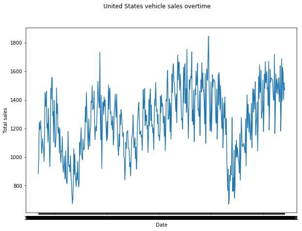

```python
x = df_TNSA['DATE'] # assign x to the date data
y = df_TNSA['TOTALNSA'] # assign y to the total data

plt.suptitle('United States vehicle sales overtime') # title the graph
plt.xlabel('Date')  # name x-axis
plt.ylabel('Total sales')  # Name y-axis
plt.gcf().set_size_inches(10,7) # Increase the size
plt.plot(x,y)
plt.show()
```

### Question: How have vehicle sales in the United States varied over time?

Using Line chart is the appropriate way to graph this type of Data (i.e. timeline data). Per above, sales varied from period to another, where it peeked at 1800 around 2005 and droped to 600s around 1981 and 2009.